# Assignment 4

Laura Ingulsrud

11/15/2018

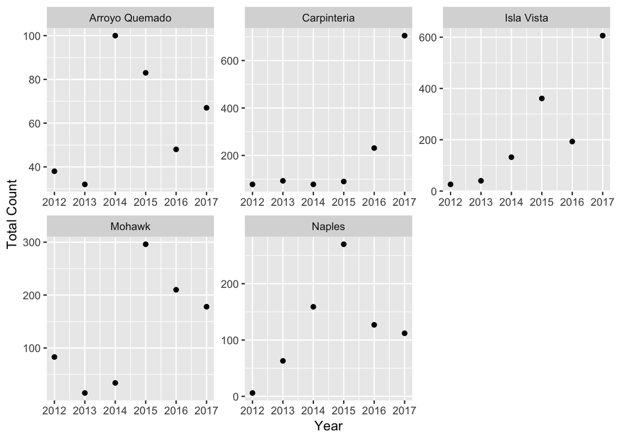

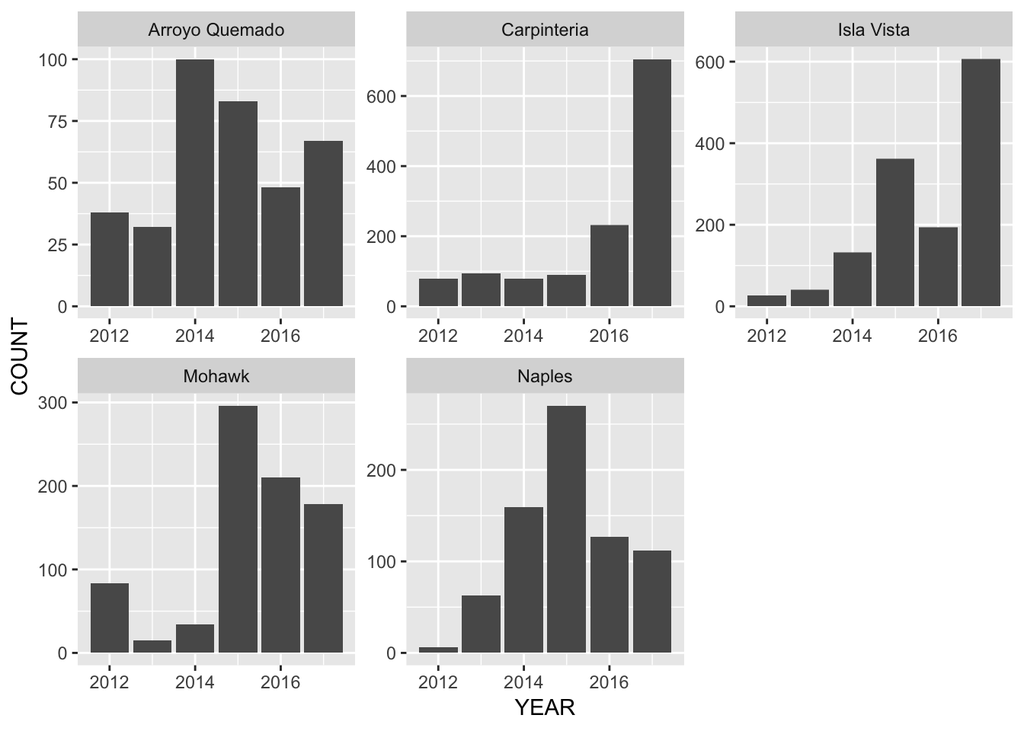

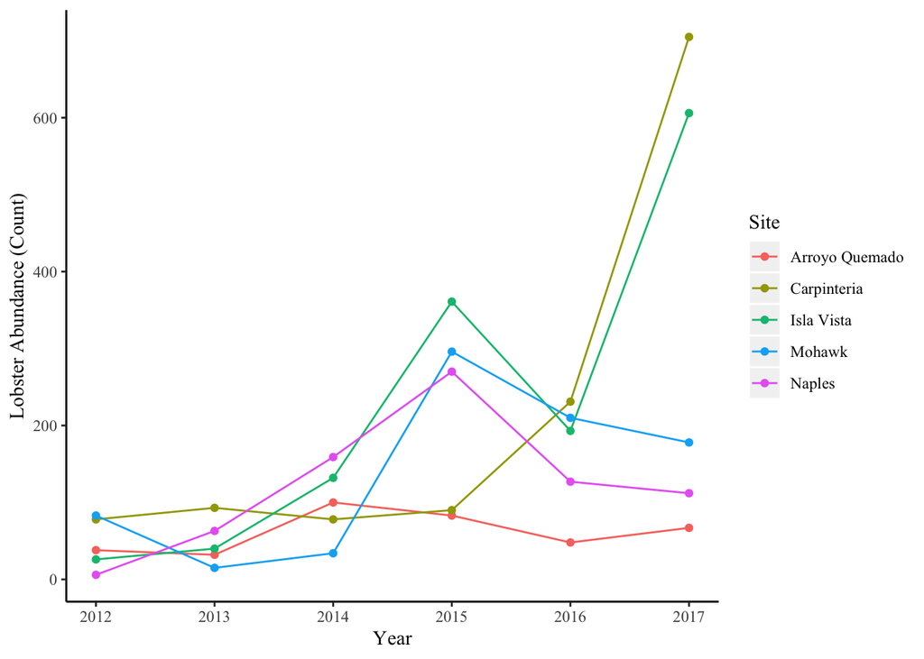

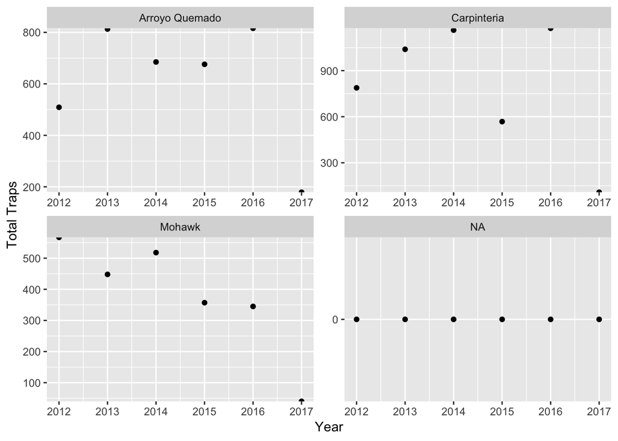

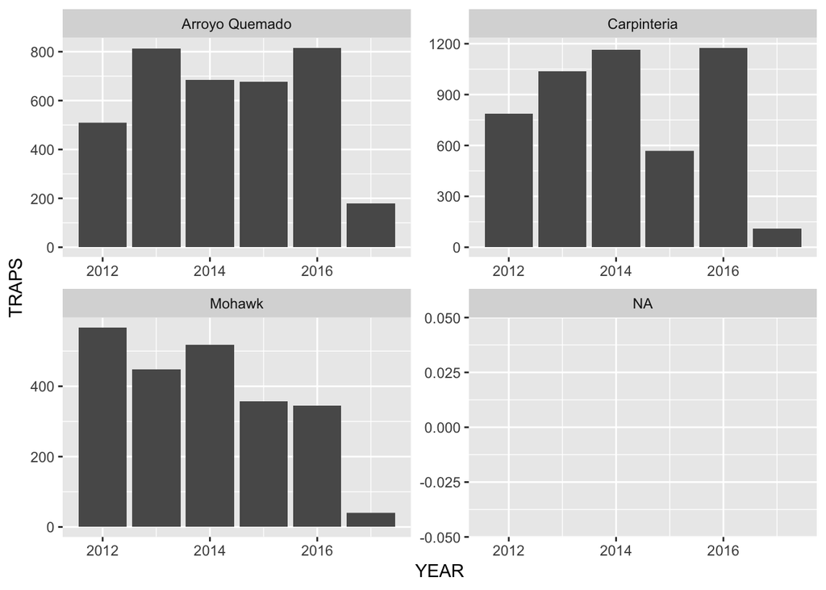

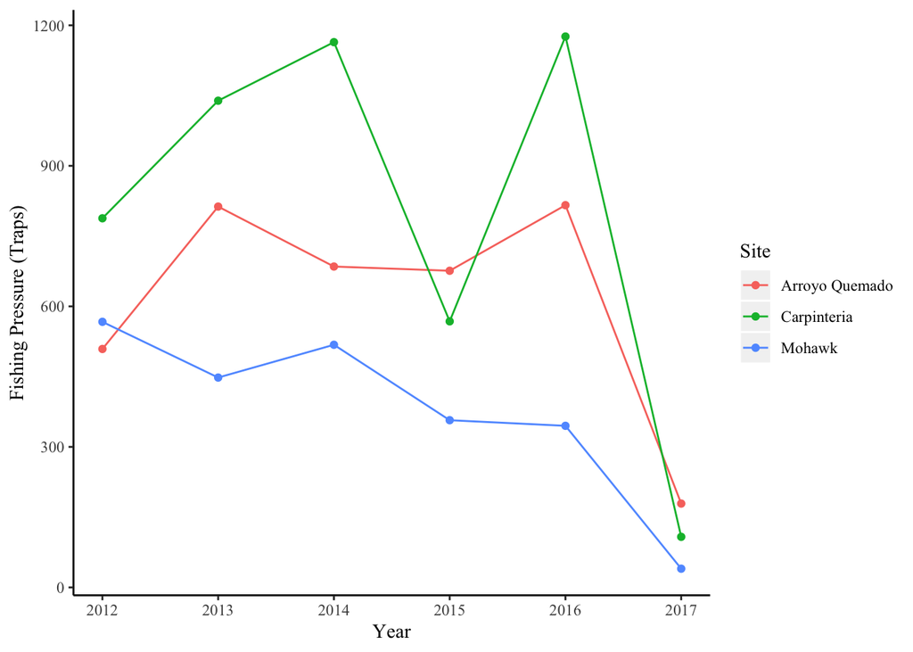

Figure 1.

Abundance of Lobster from 2012-2017: AQUE stays relatively consistent CARP starts increasing after 2015, with a big spike between 2016 and 2017 IVEE increases from 2012 to 2015, decreases from 2015 and 2016, and increases again to 2017 MOHK spikes between 2014 and 2015, then steadily decreases to 2017 NAPL increases steadily between 2012 and 2015, then decreases steadily to 2017 IVEE, MOHK, and NAPL all increase in abundance between 2013 and 2015, but then all decrease to 2016. Out of these 3 sites, only IVEE rapidly increases in abundance from 2016 to 2017; the other 2 sites (MOHK & NAPL) decrease slightly. CARP and AQUE both don’t have large changes in abundance from 2012 to 2015; after 2015, AQUE abundance decreases a little, and CARP increases, with a large increase from 2016 to 2017.

Fishing Pressure from 2012-2017 at Non-MPA Sites:

```
## # A tibble: 5 x 7
##   SITE   Mean    SD Median Maximum SampleSize    SE
##   <fct> <dbl> <dbl>  <dbl>   <dbl>      <int> <dbl>
## 1 AQUE   73.9 11.9      75     105         67 1.45
## 2 CARP   72.2 13.2      73     115        705 0.497
## 3 IVEE   71.5 14.3      70     150        606 0.582
## 4 MOHK   72    9.28     71      95        178 0.696
## 5 NAPL   76.2 11.4      78     105        112 1.08
```

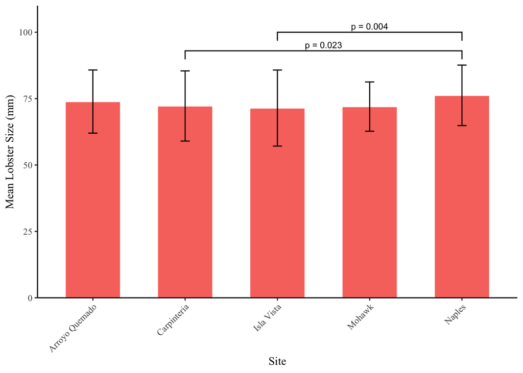

```
##               Df Sum Sq Mean Sq F value Pr(>F)
## SITE           4   2355   588.6   3.424 0.0085 **
## Residuals   1663 285871   171.9
## ---
## Signif. codes:  0 '***' 0.001 '**' 0.01 '*' 0.05 '.' 0.1 ' ' 1
```

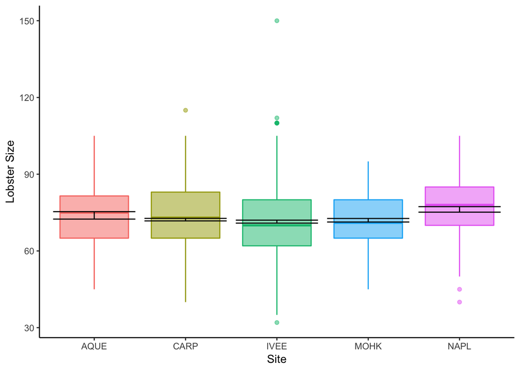

```
##   Tukey multiple comparisons of means
##     95% family-wise confidence level
##
## Fit: aov(formula = SIZE ~ SITE, data = Lob_2017_simple)
##
## $SITE
##                 diff         lwr      upr     p adj
## CARP-AQUE -1.6657352 -6.24294710 2.911477 0.8582355
## IVEE-AQUE -2.4433772 -7.05292315 2.166169 0.5968998
## MOHK-AQUE -1.8955224 -7.02720717 3.236162 0.8514711
## NAPL-AQUE  2.3366205 -3.19311600 7.866357 0.7775633
## IVEE-CARP -0.7776420 -2.76097123 1.205687 0.8216104
## MOHK-CARP -0.2297872 -3.23309697 2.773523 0.9995765
## NAPL-CARP  4.0023556  0.36042398 7.644287 0.0228728
## MOHK-IVEE  0.5478548 -2.50450730 3.600217 0.9882889
## NAPL-IVEE  4.7799976  1.09751057 8.462485 0.0037001
## NAPL-MOHK  4.2321429 -0.08607271 8.550358 0.0579286
```

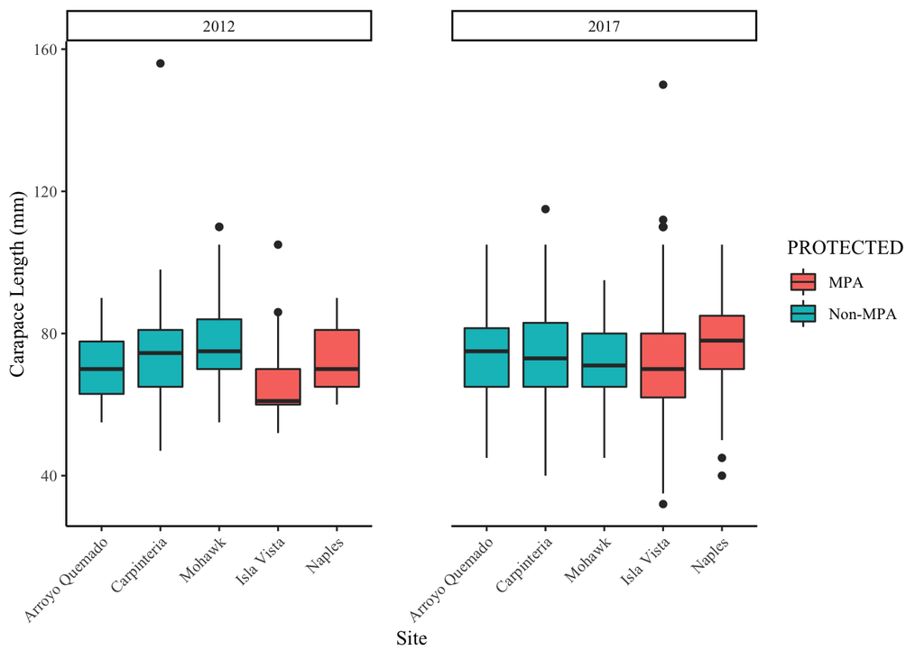

```
## [1] 83 75 60 65 65 90
```

[output not shown]

```
##
##  F test to compare two variances
##
## data:  NAPL_abun_17 and NAPL_abun_12
## F = 0.93981, num df = 111, denom df = 5, p-value = 0.7685
## alternative hypothesis: true ratio of variances is not equal to 1
## 95 percent confidence interval:
##  0.1547355 2.5214200
## sample estimates:
## ratio of variances
##           0.939807
```

```
##
##  Two Sample t-test
##
## data:  NAPL_abun_17 and NAPL_abun_12
## t = 0.67636, df = 116, p-value = 0.5002
## alternative hypothesis: true difference in means is not equal to 0
## 95 percent confidence interval:
##  -6.232765 12.697051
## sample estimates:
## mean of x mean of y
##  76.23214  73.00000
```

```
##
##  Two Sample t-test
##
## data:  NAPL_abun_17 and NAPL_abun_12
## t = 0.67636, df = 116, p-value = 0.2501
## alternative hypothesis: true difference in means is greater than 0
## 95 percent confidence interval:
##  -4.691475       Inf
## sample estimates:
## mean of x mean of y
##  76.23214  73.00000
```

```
##
## Cohen's d
##
## d estimate: 0.2834216 (small)
## 95 percent confidence interval:
##        inf        sup
## -0.5473456  1.1141889
```

```
##  [1]  70  60  65  70  85  60  65  67  70  85  52  60  64  70  58  60  60
## [18]  62  86 105  57  60  53  56  58  60
```

[output not shown]

[output cut: 21 more lines]

```
##
##  F test to compare two variances
##
## data:  IVEE_abun_17 and IVEE_abun_12
## F = 1.4023, num df = 605, denom df = 25, p-value = 0.307
## alternative hypothesis: true ratio of variances is not equal to 1
## 95 percent confidence interval:
##  0.730001 2.313236
## sample estimates:
## ratio of variances
##           1.402306
```

```
##
##  Two Sample t-test
##
## data:  IVEE_abun_12 and IVEE_abun_17
## t = -1.885, df = 630, p-value = 0.0599
## alternative hypothesis: true difference in means is not equal to 0
## 95 percent confidence interval:
##  -10.9750916   0.2246473
## sample estimates:
## mean of x mean of y
##  66.07692  71.45215
```

```
##
##  Two Sample t-test
##
## data:  IVEE_abun_12 and IVEE_abun_17
## t = -1.885, df = 630, p-value = 0.9701
## alternative hypothesis: true difference in means is greater than 0
## 95 percent confidence interval:
##  -10.07266       Inf
## sample estimates:
## mean of x mean of y
##  66.07692  71.45215
```

```
##
## Cohen's d
##
## d estimate: 0.3775177 (small)
## 95 percent confidence interval:
##         inf         sup
## -0.01633002  0.77136540
```

```
##  [1] 55 58 63 70 75 72 57 60 62 64 66 85 60 68 62 70 75 87 63 63 77 85 85
## [24] 64 65 65 70 78 80 85 88 89 90 60 65 70 72 75
```

```
##  [1]  45  75  50  60  75  80  65  88  58  60  65  70  75  75  80  80  80
## [18]  84  95  60  65  68  75  75  80  80  80  80  85  85  85  85  85  88
## [35]  92  60  60  60  65  65  65  65  65  65  70  70  70  70  70  75  75
## [52]  80  80  80  82  85  88  90  95 105  50  55  65  65  67  81  85
```

```
##
##  F test to compare two variances
##
## data:  AQUE_abun_17 and AQUE_abun_12
## F = 1.3724, num df = 66, denom df = 37, p-value = 0.2986
## alternative hypothesis: true ratio of variances is not equal to 1
## 95 percent confidence interval:
##  0.7530872 2.3858262
## sample estimates:
## ratio of variances
##           1.372436
```

```
##
##  Two Sample t-test
##
## data:  AQUE_abun_17 and AQUE_abun_12
## t = 1.2622, df = 103, p-value = 0.2097
## alternative hypothesis: true difference in means is not equal to 0
## 95 percent confidence interval:
##  -1.654312  7.445357
## sample estimates:
## mean of x mean of y
##  73.89552  71.00000
```

```
##
##  Two Sample t-test
##
## data:  AQUE_abun_17 and AQUE_abun_12
## t = 1.2622, df = 103, p-value = 0.2097
## alternative hypothesis: true difference in means is not equal to 0
## 95 percent confidence interval:
##  -1.654312  7.445357
## sample estimates:
## mean of x mean of y
##  73.89552  71.00000
```

```
##
## Cohen's d
##
## d estimate: 0.2563169 (small)
## 95 percent confidence interval:
##        inf        sup
## -0.1479675  0.6606014
```

[output not shown]

[output not shown]

[output cut: 27 more lines]

```
##
##  F test to compare two variances
##
## data:  CARP_abun_17 and CARP_abun_12
## F = 0.81672, num df = 704, denom df = 77, p-value = 0.2043
## alternative hypothesis: true ratio of variances is not equal to 1
## 95 percent confidence interval:
##  0.5712959 1.1158124
## sample estimates:
## ratio of variances
##          0.8167231
```

```
##
##  Two Sample t-test
##
## data:  CARP_abun_17 and CARP_abun_12
## t = -1.3361, df = 781, p-value = 0.1819
## alternative hypothesis: true difference in means is not equal to 0
## 95 percent confidence interval:
##  -5.257332  0.998958
## sample estimates:
## mean of x mean of y
##  72.22979  74.35897
```

```
##
##  Two Sample t-test
##
## data:  CARP_abun_17 and CARP_abun_12
## t = -1.3361, df = 781, p-value = 0.09095
## alternative hypothesis: true difference in means is less than 0
## 95 percent confidence interval:
##       -Inf 0.4950795
## sample estimates:
## mean of x mean of y
##  72.22979  74.35897
```

```
##
## Cohen's d
##
## d estimate: -0.1594364 (negligible)
## 95 percent confidence interval:
##         inf         sup
## -0.39380971  0.07493682
```

```
##
##      Two-sample t test power calculation
##
##               n = 783
##               d = 0.1416723
##       sig.level = 0.05
##           power = 0.8
##     alternative = two.sided
##
## NOTE: n is number in *each* group
```

[output not shown]

[output not shown]

```
##
##  F test to compare two variances
##
## data:  MOHK_abun_17 and MOHK_abun_12
## F = 0.76832, num df = 177, denom df = 82, p-value = 0.1509
## alternative hypothesis: true ratio of variances is not equal to 1
## 95 percent confidence interval:
##  0.5227008 1.1006996
## sample estimates:
## ratio of variances
##          0.7683238
```

```
##
##  Two Sample t-test
##
## data:  MOHK_abun_17 and MOHK_abun_12
## t = -4.0689, df = 259, p-value = 6.276e-05
## alternative hypothesis: true difference in means is not equal to 0
## 95 percent confidence interval:
##  -7.795248 -2.710776
## sample estimates:
## mean of x mean of y
##  72.00000  77.25301
```

```
##
## Cohen's d
##
## d estimate: -0.5408116 (medium)
## 95 percent confidence interval:
##        inf        sup
## -0.8066597 -0.2749635
```

```
##
##      Two-sample t test power calculation
##
##               n = 261
##               d = 0.2457094
##       sig.level = 0.05
##           power = 0.8
##     alternative = two.sided
##
## NOTE: n is number in *each* group
```

```r
# Problem 4. Proportions of “legal” lobsters at the 5 sites in 2017. The legal minimum carapace size for lobster is 82.6 mm. What proportion of observed lobsters at each site are above the legal minimum? Does that proportion differ significantly across the 5 sites? Note: We’ll be doing chi-square in labs next week, or go ahead with maximum resourcefulness and check out the chisq.test() function on your own!

# Make a contingency table for lobster carapace size:
lob_size <- lob_abun_simple %>% # Create data frame for lobster carapace size from "lob_abun_simple" data frame (created in Problem 2), which has data in tidy format
  filter(YEAR == 2017) %>%
  mutate(Legality = ifelse(SIZE < 82.6, "ILLEGAL", "LEGAL")) %>%
  select(SITE, Legality) %>%
  count(SITE, Legality) %>%
  spread(Legality, n) %>%
  select(-SITE)

rownames(lob_size) <- c("AQUE", "CARP", "IVEE", "MOHK", "NAPL")
lob_size
```

```
## # A tibble: 5 x 2
##   ILLEGAL LEGAL
## *   <int> <int>
## 1      51    16
## 2     526   179
## 3     476   130
## 4     154    24
## 5      75    37
```

```r
lob_prop <- prop.table(as.matrix(lob_size), 1) # Look at the actual proportions
lob_prop
```

```
##        ILLEGAL     LEGAL
## AQUE 0.7611940 0.2388060
## CARP 0.7460993 0.2539007
## IVEE 0.7854785 0.2145215
## MOHK 0.8651685 0.1348315
## NAPL 0.6696429 0.3303571
```

```r
# Perform chi-square test for independence on the count data (not proportions)
lob_x2 <- chisq.test(lob_size)
lob_x2
```

```
##
##  Pearson's Chi-squared test
##
## data:  lob_size
## X-squared = 18.497, df = 4, p-value = 0.0009864
```

```r
lob_x2$stdres # If beyond 2, pay attention for significance...
```

```
##         ILLEGAL      LEGAL
## AQUE -0.1464223  0.1464223
## CARP -1.8631463  1.8631463
## IVEE  1.2357993 -1.2357993
## MOHK  3.2327773 -3.2327773
## NAPL -2.5706474  2.5706474
```

```r
# There IS a significant association between legal lobster size between the 5 sites! Look at 'Values' section to see what things you can call from the output.

# create kable table of proportion of legal lobsters at each site
lob_table <- kable(lob_prop) %>%
  kable_styling(bootstrap_options = c("striped", "hover", "bordered"), full_width = F, position = "left")
lob_table
```

|  | ILLEGAL | LEGAL |
| --- | --- | --- |
| AQUE | 0.7611940 | 0.2388060 |
| CARP | 0.7460993 | 0.2539007 |
| IVEE | 0.7854785 | 0.2145215 |
| MOHK | 0.8651685 | 0.1348315 |
| NAPL | 0.6696429 | 0.3303571 |

```r
# need to change to percentages in the table
```

The proportion of observed lobsters at a legal size differed significantly across the 5 sites ($\chi^2$(4) = 18.5, p < 0.001, $\alpha$ = 0.05.) Most notably, Mohawk Reef had a higher proportion of illegal lobster size, while Naples had a higher proportion of legal lobster size compared to the rest of the 5 sites.